# isoforest

**Isolation Forest is an ensemble-based algorithm specifically designed for anomaly detection. It works by isolating observations in a dataset. Here’s a deeper look at how it functions and its evaluation:**

**Isolation Principle: The main idea is that anomalies are easier to isolate compared to normal observations. The algorithm creates a series of random partitions (trees) in the feature space.**

## Tree Construction:

**For each tree, random features and random split values are selected. This process continues until each data point is isolated.**

## Scoring:

**The length of the path to isolate a point is indicative of its anomaly score. Points that require shorter paths are considered outliers, as they can be isolated quickly.**

## Final Decision:

After constructing multiple trees, the model aggregates the results and assigns an anomaly score to each point. Those with scores below a certain threshold (determined by contamination) are flagged as outliers.**

```python
import numpy as np
import pandas as pd
import plotly.express as px
import plotly.offline as pyo

import seaborn as sns
import matplotlib.pyplot as plt

from sklearn.ensemble import IsolationForest
```

```python
data = pd.read_csv('https://storage.googleapis.com/esmartdata-courses-files/ml-course/factory.csv')
data.head()
```

|  | item_length | item_width |
| --- | --- | --- |
| 0 | 6.206380 | 5.618286 |
| 1 | 5.756649 | 5.921924 |
| 2 | 5.576329 | 5.792401 |
| 3 | 5.304950 | 7.235000 |
| 4 | 6.764064 | 5.965792 |

```python
data.describe()
```

|  | item_length | item_width |
| --- | --- | --- |
| count | 400.000000 | 400.000000 |
| mean | 5.824371 | 5.927004 |
| std | 1.040374 | 1.035379 |
| min | 0.117702 | 0.592448 |
| 25% | 5.237362 | 5.410112 |
| 50% | 5.907650 | 5.984139 |
| 75% | 6.464539 | 6.513579 |
| max | 8.091519 | 8.365203 |

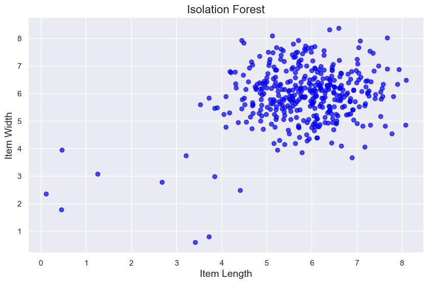

```python
plt.figure(figsize=(10, 6))  # Set the size of the plot
plt.scatter(data['item_length'], data['item_width'], color='blue', alpha=0.7)

# Set the title and labels
plt.title('Isolation Forest', fontsize=16)
plt.xlabel('Item Length', fontsize=14)
plt.ylabel('Item Width', fontsize=14)

# Show the plot
plt.grid(True)  # Optional: add grid
plt.show()
```

**An IsolationForest model is initialized with 100 estimators and a contamination rate of 0.05. The contamination parameter indicates the proportion of outliers in the dataset (5%).**

```python
outlier = IsolationForest(n_estimators=100, contamination=0.05)
outlier.fit(data)
```

```
IsolationForest(contamination=0.05)
```

```python
y_pred = outlier.predict(data)
y_pred
```

```
array([ 1,  1,  1,  1,  1,  1,  1,  1,  1,  1,  1,  1,  1,  1,  1,  1,  1,
        1, -1,  1,  1,  1,  1,  1,  1,  1, -1,  1,  1,  1,  1,  1,  1,  1,
        1,  1,  1,  1,  1,  1,  1,  1,  1,  1,  1,  1,  1,  1,  1,  1,  1,
        1,  1,  1,  1,  1,  1,  1,  1,  1,  1,  1,  1,  1,  1,  1,  1,  1,
        1,  1,  1,  1,  1,  1,  1,  1,  1,  1,  1,  1,  1,  1,  1,  1,  1,
        1,  1,  1,  1,  1,  1,  1,  1,  1,  1,  1,  1,  1,  1,  1,  1, -1,
        1,  1,  1,  1,  1,  1,  1,  1,  1,  1,  1,  1,  1,  1,  1,  1,  1,
        1,  1,  1,  1,  1,  1,  1,  1,  1,  1,  1, -1,  1,  1,  1,  1,  1,
        1,  1,  1,  1,  1,  1,  1,  1,  1,  1,  1,  1,  1,  1,  1,  1,  1,
        1,  1,  1,  1,  1,  1,  1,  1,  1,  1,  1,  1,  1,  1,  1,  1,  1,
        1,  1,  1,  1,  1,  1,  1,  1, -1,  1,  1,  1,  1,  1,  1,  1,  1,
        1,  1,  1,  1,  1,  1,  1,  1,  1,  1,  1,  1,  1,  1,  1,  1,  1,
        1,  1,  1,  1,  1,  1,  1,  1,  1, -1,  1,  1,  1,  1,  1,  1,  1,
        1,  1,  1,  1,  1,  1,  1,  1,  1,  1,  1,  1,  1,  1, -1,  1,  1,
        1,  1,  1,  1,  1,  1,  1,  1,  1,  1,  1,  1,  1,  1,  1,  1,  1,
        1,  1,  1,  1,  1,  1,  1,  1,  1,  1,  1,  1,  1,  1,  1,  1,  1,
        1,  1,  1,  1,  1,  1,  1,  1,  1,  1,  1,  1,  1,  1,  1,  1,  1,
        1,  1,  1,  1,  1,  1,  1,  1,  1,  1,  1,  1,  1, -1,  1,  1,  1,
        1,  1,  1,  1,  1, -1,  1,  1,  1,  1,  1,  1,  1,  1,  1,  1,  1,
        1,  1,  1,  1,  1,  1,  1,  1,  1,  1,  1,  1,  1,  1,  1,  1,  1,
        1,  1,  1,  1,  1,  1,  1,  1,  1,  1,  1,  1,  1,  1,  1,  1,  1,
        1,  1,  1,  1,  1,  1,  1,  1,  1,  1,  1,  1,  1,  1,  1,  1,  1,
        1,  1,  1,  1,  1,  1,  1,  1, -1,  1,  1,  1,  1,  1, -1, -1, -1,
        1,  1, -1, -1, -1, -1, -1, -1, -1])
```

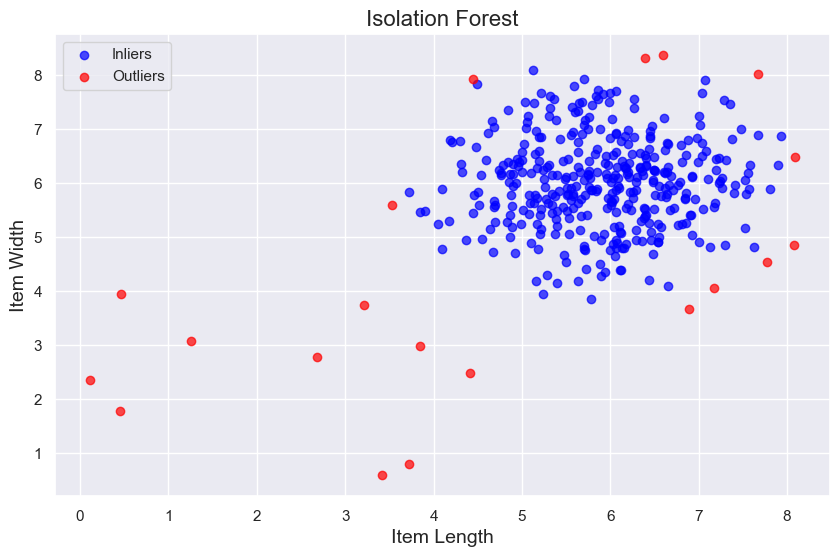

```python
data['outlier_flag'] = y_pred
plt.figure(figsize=(10, 6))  # Set the size of the plot

# Plot inliers (1) and outliers (-1) with different colors
plt.scatter(data[data['outlier_flag'] == 1]['item_length'],
            data[data['outlier_flag'] == 1]['item_width'],
            color='blue', label='Inliers', alpha=0.7)

plt.scatter(data[data['outlier_flag'] == -1]['item_length'],
            data[data['outlier_flag'] == -1]['item_width'],
            color='red', label='Outliers', alpha=0.7)

# Set the title and labels
plt.title('Isolation Forest', fontsize=16)
plt.xlabel('Item Length', fontsize=14)
plt.ylabel('Item Width', fontsize=14)

# Add a legend
plt.legend()

# Show the plot
plt.grid(True)  # Optional: add grid
plt.show()
```

**Understanding the characteristics of these outliers and validating the model against any known issues is critical for deploying an anomaly detection solution effectively.**